# Exercises

1. Take 3 of your own photos of food and use the trained model to make predictions on them, share your predictions with the other students in Discord and show off your Food Vision model 🍔👁.
2. Train a feature-extraction transfer learning model for 10 epochs on the same data and compare its performance versus a model which used feature extraction for 5 epochs and fine-tuning for 5 epochs (like we've used in this notebook). Which method is better?
3. Recreate our first model (the feature extraction model) with mixed_precision turned on.
- Does it make the model train faster?
- Does it effect the accuracy or performance of our model?
- What's the advatanges of using mixed_precision training?

## 1. Let model predict on 3 custom photos you've taken

Let's first figure out the steps to take with our empty workbook:

1. load in our saved `big dog model` - '101_food_class_10_percent_saved_big_dog_model' with `tf.keras.models.load_model`
2. create a function `load_and_prep_model`, so we can put our make our images into tensors for the model to read/predict on
3. add the `class_names` variable, by inputting our `test_data` into this workbook - might as well set up `test_data` so it's usable for the other exercises
4. create a loop through our 3 custom image folder, and visually display the results, with the prediction from the model.

Let's start with loading our `big dog model`.

```python
# load model into workbook
import tensorflow as tf

saved_model_path = '101_food_class_10_percent_saved_big_dog_model'
model = tf.keras.models.load_model(saved_model_path)
```

We'll pretty much copy the `load_and_prep_model` function from the workbook. Never copy paste! Must copy by hand for better hands on learning :)

```python
def load_and_prep_image(filename, img_shape=224, scale=True):
    '''
    Function reads an image, turns it into a tensor and resize it to (224,224,3)

    Variables:
    filename (str) - name of file for target image
    img_shape (int) - image shape the model works with
    scale (bool) - whether scaling pixel values between 0 and 1 is necessary, based on model we're using
    '''

    # read in the image
    img = tf.io.read_file(filename)
    # decode it into a tensor
    img = tf.io.decode_image(img)
    # resize the image
    img = tf.image.resize(img, [img_shape, img_shape])
    if scale:
        # rescale image to between 0 and 1
        return img/255.0
    else:
        return img
```

We'll need to input the `class_names` of the food, so we actually get a name representation, not a integer index value.

But firstly, let's pull in test directory, and create `test_data`.

```python
# create test_data, then create class_name list
test_dir = '101_food_classes_10_percent/test/'

test_data = tf.keras.preprocessing.image_dataset_from_directory(test_dir,
                                                                label_mode='categorical',
                                                                image_size=(224,224),
                                                                shuffle=False) # no shuffle, else we can't recreate same training order, and compare results

# pull class names from test_data into it's own variable
class_names = test_data.class_names
```

```
Found 25250 files belonging to 101 classes.
```

```python
class_names
```

```
['apple_pie',
 'baby_back_ribs',
 'baklava',
 'beef_carpaccio',
 'beef_tartare',
 'beet_salad',
 'beignets',
 'bibimbap',
 'bread_pudding',
 'breakfast_burrito',
 'bruschetta',
 'caesar_salad',
 'cannoli',
 'caprese_salad',
 'carrot_cake',
 'ceviche',
 'cheese_plate',
 'cheesecake',
 'chicken_curry',
 'chicken_quesadilla',
 'chicken_wings',
 'chocolate_cake',
 'chocolate_mousse',
 'churros',
 'clam_chowder',
 'club_sandwich',
 'crab_cakes',
 'creme_brulee',
 'croque_madame',
 'cup_cakes',
 'deviled_eggs',
 'donuts',
 'dumplings',
 'edamame',
 'eggs_benedict',
 'escargots',
 'falafel',
 'filet_mignon',
 'fish_and_chips',
 'foie_gras',
```

[output cut: 46 more lines]

```
 'sashimi',
 'scallops',
 'seaweed_salad',
 'shrimp_and_grits',
 'spaghetti_bolognese',
 'spaghetti_carbonara',
 'spring_rolls',
 'steak',
 'strawberry_shortcake',
 'sushi',
 'tacos',
 'takoyaki',
 'tiramisu',
 'tuna_tartare',
 'waffles']
```

Now we can create a loop of custom images and then visually display the results from the model's prediction

But first, we need to gather the filepath for custom image

```python
# get filepath of custom image
import os

custom_food_image = ['my_custom_food_image/' + img_path for img_path in os.listdir('my_custom_food_image')]
custom_food_image
```

```
['my_custom_food_image/20251113_222110.jpg',
 'my_custom_food_image/20251113_222254.jpg',
 'my_custom_food_image/20251113_222134.jpg']
```

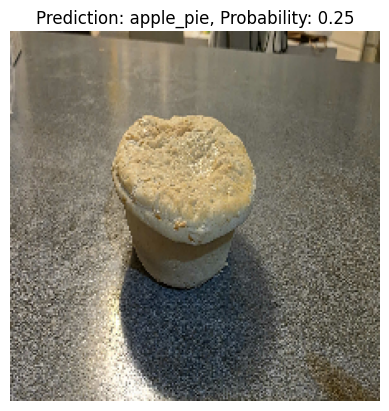

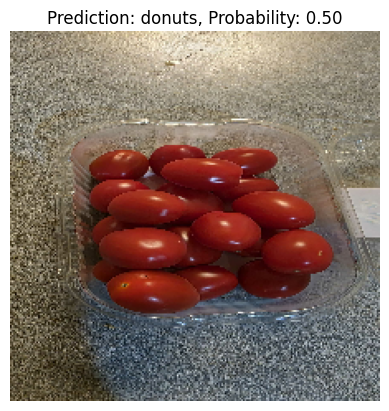

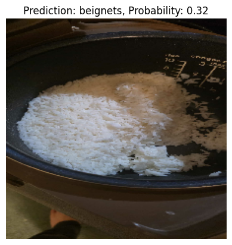

```python
# make predictions on the custom image
import matplotlib.pyplot as plt

for img in custom_food_image:
    img = load_and_prep_image(img,scale=False) # load target image and turn into tensor
    pred_prob = model.predict(tf.expand_dims(img,axis=0)) # expand image dims for model to input batch num
    pred_class = class_names[pred_prob.argmax()] # find predicted class by highest probability

    # plot the image
    plt.figure()
    plt.imshow(img/255.) # normalize values
    plt.title(f'Prediction: {pred_class}, Probability: {pred_prob.max():.2f}')
    plt.axis(False)
```

Here are the following images that the model predicts my food image is:

Apple pie:

[figure not shown]

In reality it's a meat pie.

Donut:

[figure not shown]

In reality it's a cherry tomato.

Beignets:

[figure not shown]

In reality it's rice.

Based on the results the model produced, I can sort of understand why they chose these predictions, more so for rice, less so for cherry tomato.

Rice was predicted as beignets, most likely due to the model flagging it's white colour for the icing sugar on the beignets. And you can see how much dusting the beignets get with icing sugar alone, making most of the food pure white.

Meat pie was predicted as apple pie, most likely due to how majority of pies all have a distinct pastry bowl and cover shape. It also didn't help how the pie pastry was not breached, therefore you cannot determine the type of filling is in it with just the pastry outside, however caveat to that is apple pies do have a very distinct criss cross pastry design on top where you can see through to the filling, while most meat pies come with a solid pastry lid.

Cherry tomato is a weird one, the only way I can think of it's prediction as a 'donut' is those dunkin donuts munchkins, or the tim horton's timbits, aka those doughnut holes. But it seems too red to be anything of matching to the pastry and it's colourfulness of the food.

**Note**: The pictures of the food were taken very unorthodox, and not presented as a dish on a plate with other sides and accessories. I simply pulled out whatever food objects I had at home and take a few quick pictures to speed up the process, but to also see how much I can stress the model. Even 2 of the food objects aren't really classified as `dishes` themselves, since the model has only been trained on dish types of food, with many contributing pieces and entrees, while mine is a bunch of singular food items that can be incorporated into a dish.

Given that, the model still made pretty good educational guesses.

### 2. Train a feature-extraction transfer learning model for 10 epoch, versus a model which used feature extraction for 5 epochs and fine-tuning for 5 epochs

We have already done the 5 feature extraction, 5 fine tuned model on the previous workbook, and saved it as well. So for this exercise, we only need to model train 10 epoch feature extraction. Once done, we can compare this via evaluation of `test_data`, in addition to visually compare/contrast their loss and accuracy curves while training 10 epochs.

The list of steps are as follows:

1. Instantiate `helper_functions` for some quick easy functions to use during this exercise, rather than creating our own.
2. Get train directory, and create our train dataset to be trained on
3. Create an augmentation sequential model, which gives image data variety to the model
4. Set up base model, and functional api model. Make sure all trainable features of base model is set to `False`, only leaving adam lr weights changeable
5. Now evaluate them, and visually check and contrast both models with their `loss` and `accuracy` values between the graphs, and evaluation info

Let's get our helper function into the workbook

```python
# import helper functions into workbook - we've already downloaded it
from helper_functions import create_tensorboard_callback, plot_loss_curves, unzip_data, walk_through_dir, compare_historys
```

Next, get our training directory, and create our training data with `image_dataset_from_directory`

```python
# create train dataset like we did for test data
train_dir = '101_food_classes_10_percent/train/'

train_data_all_10_percent = tf.keras.preprocessing.image_dataset_from_directory(train_dir,
                                                                                label_mode='categorical',
                                                                                image_size=(224,224))
```

```
Found 7575 files belonging to 101 classes.
```

Let's create the augmentation sequential model, to give more variety of type of image data the model may recieve. (Also, this is so we can keep in line with previous experiments, as it is an independent variable that must be kept in control of, so we can truly see what transfer learning does, compared to transfer learning half, then fine tune half.)

```python
# create augmentation model
from tensorflow.keras import layers
from tensorflow.keras.models import Sequential

data_augmentation = Sequential([
    layers.RandomFlip('horizontal'),
    layers.RandomRotation(0.2),
    layers.RandomZoom(0.2),
    layers.RandomHeight(0.2),
    layers.RandomWidth(0.2),
    # preprocessing.Rescaling(1./255) # keep for ResNet40V2, remove for EfficientNetB0 as they do this process automatically
], name='data_augmentation')
```

Now let's set up our base model and recreate the functional API model.

For our base model, we remove the top classified layer, as it is shaped entirely different to our data (it has 1000 categories), but have to make sure our `input_size` is stated, else the layers won't know what to expect,

Recreate our model, and add input layer as well, so all layers in our functional api needs to know the `input_shape` to expect, not just base model. Remember this is feature extracting, so no training weights on base model. Only thing that's changing freely are our augmentation model, and Adam weights when compiling.

**Note**: `Trainable.` freezes the weights, and `Training` freezes the normalized/dropout/scaled values, aka weights that pull the strings from behind.

> Aka we have a model that predicts weight of potatoes in kilograms. `Trainable` is the data (potatoes, mushrooms) and `Training` is the scale (kilogram, pounds and ounces).

```python
# setup base model and freeze its layers (our feature extractor)
base_model = tf.keras.applications.EfficientNetB0(include_top=False, weights='imagenet', input_shape=(224,224,3))
base_model.trainable = False # freeze our weights in layers

# setup model architecture with trainable top layer
inputs = layers.Input(shape=(224,224,3), name='input_layer') # shape of input image
x = data_augmentation(inputs) # augment our training images
x = base_model(x, training=False) # put base model in inference mode, so no scaling weights are updated - thus it is truly a feature extracting model
x = layers.GlobalAveragePooling2D(name='global_average_pooling')(x) # pool the ouputs of base model into 1D data, so outputs can read them
outputs = layers.Dense(len(train_data_all_10_percent.class_names), activation='softmax', name='output_layer')(x) # create output, with same number of classes for model to use on predicting class
model = tf.keras.Model(inputs, outputs)
```

Let's check the model summary for a moment, to see if anything obvious is broken

```python
# check model summary
model.summary()
```

[output not shown]

```python
# compile the model
model.compile(loss='categorical_crossentropy',
              optimizer=tf.keras.optimizers.Adam(), # we're using Adam's default lr
              metrics=['accuracy'])

# fit the model
history_all_classes_10_percent = model.fit(train_data_all_10_percent,
                                           epochs=10,
                                           validation_data=test_data,
                                           validation_steps=int(0.15 * len(test_data)), # evaluate on 15% of test data to keep experiments quick
                                           )
```

Let's plot out the training curve thru epochs.

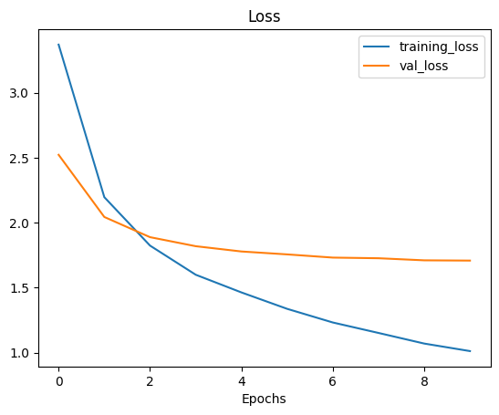

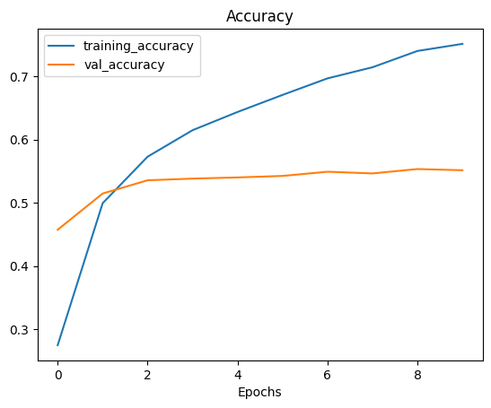

```python
plot_loss_curves(history_all_classes_10_percent)
```

And this is the following, 5 epoch transfer learning, and 5 epoch fine tuning curve graph:

[figure not shown]

When we visually compare both curves, we can see how the fine tuned version achieved better training loss and accuracy, comparative to full transfer learning model. This is based on the numbered axis compression, which is slightly more compressed on `fine tune` over `transfer learning`, and the line also seem to go a bit more lower.

However, both have very similar line tapering, indicating that this can likely be the pre-trained model's limiting factor, not because of the way we trained. They both have overfitted on the `training data`, the more epochs it is trained on, while `test loss` and `accuracy` has essentially flatlined, and may have even reversed improvements.

Based on what our eyes can see, it's very difficult to definitively prove which model is better, thus we will have to evaluate both models on the full test model, and see the loss and accuracy value between the two.

```python
# evaluate model on the full test dataset, and check it's results

results_10_epoch_transfer = model.evaluate(test_data)
results_10_epoch_transfer
```

```
[1.4992332458496094, 0.5980989933013916]
```

We've got an accuracy value of 59.81% from the `10 epoch transfer learning` model.

Now it's time to evaluate the `5 transfer learning, 5 fine tuning epoch` model. - First we'll import the saved model into the workbook.

```python
# evaluate transfer learning/fine tuning model

fine_tuning_model_path = '06_101_food_class_10_percent_saved_big_dog_model'
fine_tuned_model = tf.keras.models.load_model(fine_tuning_model_path)
```

```
WARNING:tensorflow:SavedModel saved prior to TF 2.5 detected when loading Keras model. Please ensure that you are saving the model with model.save() or tf.keras.models.save_model(), *NOT* tf.saved_model.save(). To confirm, there should be a file named "keras_metadata.pb" in the SavedModel directory.
```

[output not shown]

[output cut: 81 more lines]

```python
results_fine_tune_model = fine_tuned_model.evaluate(test_data)
results_fine_tune_model
```

```
[1.8027207851409912, 0.6077623963356018]
```

```python
print(f'{results_10_epoch_transfer}\n{results_fine_tune_model}')
```

```
[1.4992332458496094, 0.5980989933013916]
[1.8027207851409912, 0.6077623963356018]
```

We can actually see the fine tuned version of the model, just very slightly beat out our transfer learning only model, by barely a percentage! (At 60.78%)

Usually fine tuning does a pretty good job at further improving a model's ability to cater towards our custom data, but it may have looked like the model has been optimized as well as it could.

### 3. Recreate our first model (the feature extraction model) with mixed_precision turned on.

> But first of all, what is `mixed precision`?

Mixed Precision is where the model uses a mix of `float16` and `float32`. Some layers (especially matrix multiplications) run on `float16`, while others (like BatchNorm) stay in `float32`.

This helps with huge speedup in training with modern GPUs, lowers memory usage (allowing bigger batch sizes), and improves training stability.

You see most of it's benefit on training deep CNNs (EfficientNet, ResNet, Vision Transformers, etc.)

1. Let's import `mixed_precision`, and set global policy to `mixed_float16`.
2. Recreate our feature extraction model, but make sure output layer is `float32`.
3. Recreate model compiling, and then begin training 10 epochs of the model.

So let's import `mixed_precision` and set up `mixed_float16`.

```python
# import mixed precision to allow mix of float16
from tensorflow.keras import mixed_precision

mixed_precision.set_global_policy('mixed_float16')
```

```
WARNING:tensorflow:Mixed precision compatibility check (mixed_float16): WARNING
The dtype policy mixed_float16 may run slowly because this machine does not have a GPU. Only Nvidia GPUs with compute capability of at least 7.0 run quickly with mixed_float16.
If you will use compatible GPU(s) not attached to this host, e.g. by running a multi-worker model, you can ignore this warning. This message will only be logged once
```

[output not shown]

Now recreate our model again - but make sure we name it different to avoid conflict with our previous model, and that output is also `float32`.

**Why `float32`?** It's due to how big the values get, once you reach the dense layer + softmax. `float16` max value is 6.5e4, whilst `float32` max value is 3.4e38. If the value is too big for `float16` to read, then it would simply be treated as `inf` or `NaN`, which would break things very quickly.

```python
# setup base mode again
base_model = tf.keras.applications.EfficientNetB0(include_top=False, weights='imagenet', input_shape=(224,224,3))
base_model.trainable=False

# setup model architecture
inputs = layers.Input(shape=(224,224,3), name='input_layer')
x = data_augmentation(inputs)
x = base_model(x, training=False)
x = layers.GlobalAveragePooling2D(name='global_average_pooling')(x)

# keep output layer as float32
outputs = layers.Dense(len(train_data_all_10_percent.class_names), activation='softmax', dtype='float32', name='output_layer')(x)
model_mix_precise = tf.keras.Model(inputs, outputs)
```

Let's have a look at the model summary

```python
model_mix_precise.summary()
```

```
Model: "model_3"
_________________________________________________________________
 Layer (type)                Output Shape              Param #
=================================================================
 input_layer (InputLayer)    [(None, 224, 224, 3)]     0

 data_augmentation (Sequent  (None, None, None, 3)     0
 ial)

 efficientnetb0 (Functional  (None, 7, 7, 1280)        4049571
 )

 global_average_pooling (Gl  (None, 1280)              0
 obalAveragePooling2D)

 output_layer (Dense)        (None, 101)               129381

=================================================================
Total params: 4178952 (15.94 MB)
Trainable params: 129381 (505.39 KB)
Non-trainable params: 4049571 (15.45 MB)
_________________________________________________________________
```

```python
# compile the model
model.compile(loss='categorical_crossentropy',
              optimizer=tf.keras.optimizers.Adam(),
              metrics=['accuracy'])

# fit the model
history_all_classes_10_percent_mixed_precision = model.fit(train_data_all_10_percent,
                                                           epochs=10,
                                                           validation_data=test_data,
                                                           validation_steps=int(0.15*len(test_data)))
```

[output not shown]

[output cut: 57 more lines]

[output not shown]

From what ChatGPT has suggested, the speed up on modern GPU training can be 1.5 to 3 times faster, or even 2 to 4 times with larger batch sizes.

#### So the question is:

**Does it make the model train faster?**

It depends on your hardware. With modern GPUs, it will see some significant boosts in speed. But this is the opposite case for CPU only training.

**Does it effect the accuracy or performance of our model?**

This would be unsure, since I'm not keen on waiting hours for it to run on my setup. My thoughts based on what has been said, is that it doesn't change much in accuracy. The main benefit is the speed of training.

**What's the advatanges of using mixed_precision training?**

Much faster training, therefore you're able to complete any experiments and project at a faster rate, since there's less inbetween waiting for the model to finish training. But it's only advantageous if you have the right hardware to use `mixed_precision`, and it helps if you're able to install all the damn softwares and it's nit picky versions, to actually get tensorflow to recognize that you have a GPU on your PC.